# Homework 4

Nathan Friedrichsen

**Due: Sunday 10/18 at 11:59pm.** An extra two days have been allotted to reduce time pressure from the project.

This assignment is intended to practice `dplyr` and `ggplot2` skills.

# ICU Admissions

Intensive care units, or ICUs, are primary spaces in hospitals that are reserved for patients in critical condition. The data below is a random sample of n = 200 ICU patients from a research hospital affiliated with Carnegie Mellon University (CMU).

```r
icu = read.csv("https://nfriedrichsen.github.io/data/icu.csv")
```

The data dictionary below documents each variable that was recorded:

- **ID** - Patient ID number
- **Status** - Patient status: 0=lived or 1=died
- **Age** - Patient’s age (in years)
- **Sex** - 0=male or 1=female
- **Race** - Patient’s race: 1=white, 2=black, or 3=other
- **Service** - Type of service: 0=medical or 1=surgical
- **Cancer** - Is cancer involved? 0=no or 1=yes
- **Renal** - Is chronic renal failure involved? 0=no or 1=yes
- **Infection** - Is infection involved? 0=no or 1=yes
- **CPR** - Patient received CPR prior to admission? 0=no or 1=yes
- **Systolic** - Systolic blood pressure (in mm of Hg)
- **HeartRate** - Pulse rate (beats per minute)
- **Previous** - Previous admission to ICU within 6 months? 0=no or 1=yes
- **Type** - Admission type: 0=elective or 1=emergency
- **Fracture** - Fractured bone involved? 0=no or 1=yes
- **PO2** - Partial oxygen level from blood gases under 60? 0=no or 1=yes
- **PH** - pH from blood gas under 7.25? 0=no or 1=yes
- **PCO2** - Partial carbon dioxide level from blood gas over 45? 0=no or 1=yes
- **Bicarbonate** - Bicarbonate from blood gas under 18? 0=no or 1=yes
- **Creatinine** - Creatinine from blood gas over 2.0? 0=no or 1=yes
- **Consciousness** - Level upon arrival: 0=conscious, 1=deep stupor, or 2=coma

### Question 1

**Part A**: Filter the ICU data to include only patients whose visit involves an infection. Then, for the “Age” variable, find the mean, standard deviation, and group size of patients with and without a previous admission in the prior 6 months.

**Part B**: Considering all ICU patients in these data, add a column to the data set that represents sex-specific Z-score for the variable “HeartRate” of each patient. *Note*: you should be using different means and standard deviations within each sex to calculate this Z-score.

**Part C**: Using your results from Part B, recreate the following `ggplot` graphic:

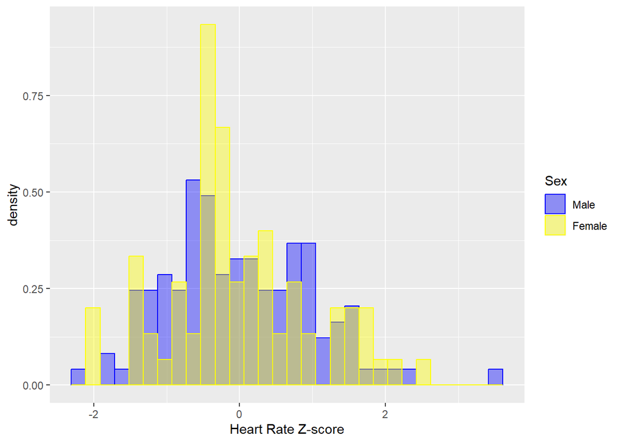

*Hints*: The code used to generate this graph uses `aes(y = after_stat(density))` to put the histograms on the density scale, and `position = "identity"` to allow them to overlap rather than stack. The graphics parameter `alpha` was used to provide partial transparency.

### Question 2

Using the `icu` data, recreate the following figure. Then briefly describe what this graph shows us about potential relationships between variables.

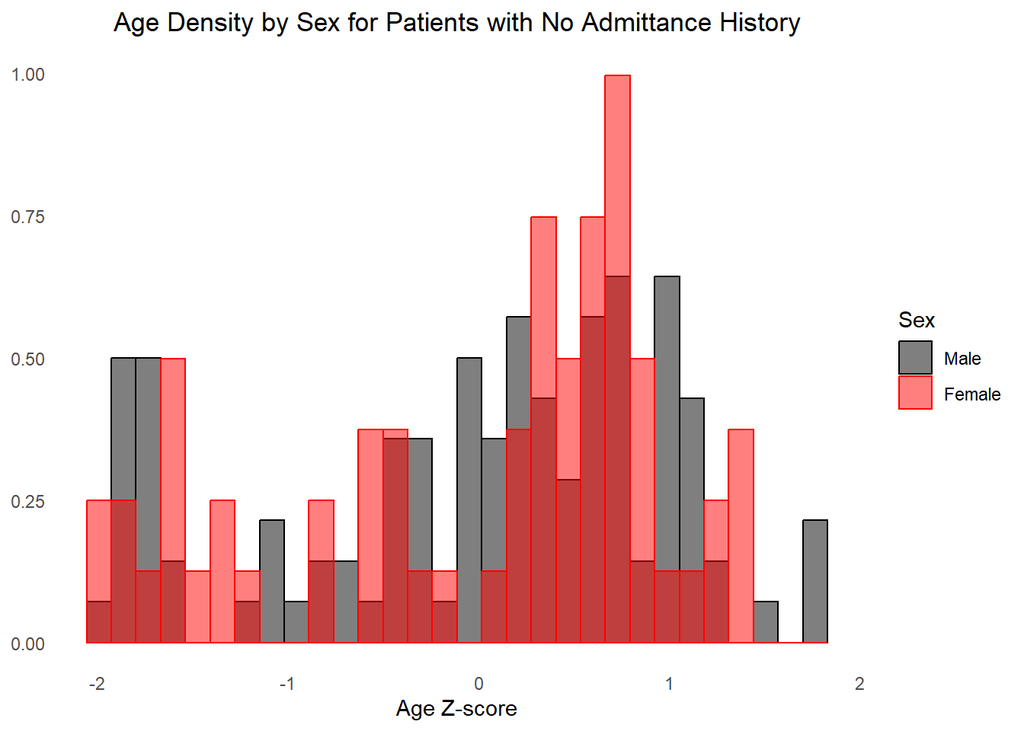

*Hints*: There is a filter using the Previous variable so no previous admits are included.

### Question 3

Pick three (3) variables from this data set, two (2) of which must be variables not used in the previous two questions of this assignment. Make a polished graphic that displays the relationship between these variables, justify your particular graphic choice and modifications, and briefly describe what we have learned from the graph.